# Credit Card Fraud Detection

Cheikhou Kane

9/24/2019

In the following, we will be investigating a dataset of 284,807 credit card transactions in order to train a model that would detect fraudulent transactions.

## 1. Exploring the dataset

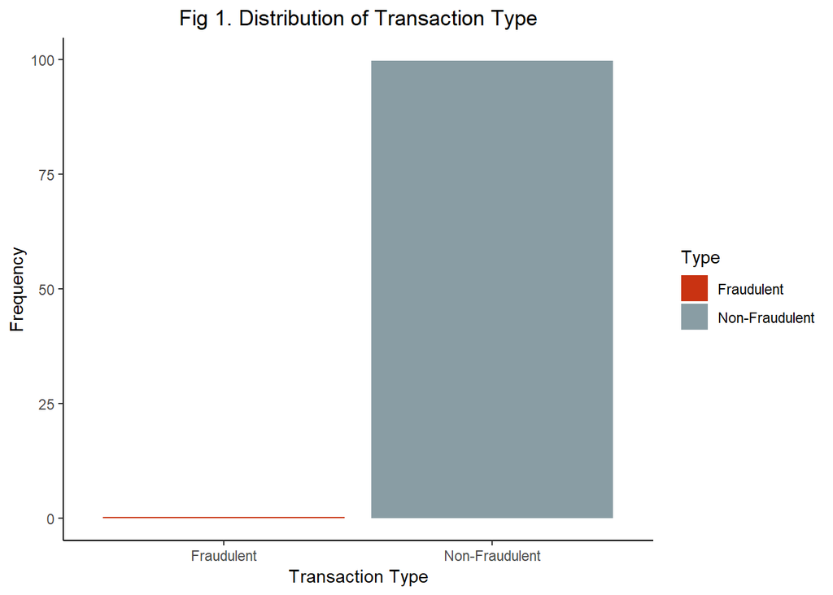

We have an imbalanced dataset: only about .2 % of the transactions were fraudulent (492 out of 284807) as shown below. Training any model using this dataset would hence bias the predictions towards the more common class, Non-Fraudulent, in our case. Since we want our model to detect patterns that give signs of fraud, it is important to take note of this as we dive further into analysis.

Table 1. Distribution of Transaction Type

| Type | Count | Cost |
| --- | --- | --- |
| Non-Fraudulent | 284315 | 25102462 |
| Fraudulent | 492 | 60128 |

Despite their scarcity, the fraudulent transactions totaled over 60,000€ (65,730$): not detecting fraud can be quite costly.

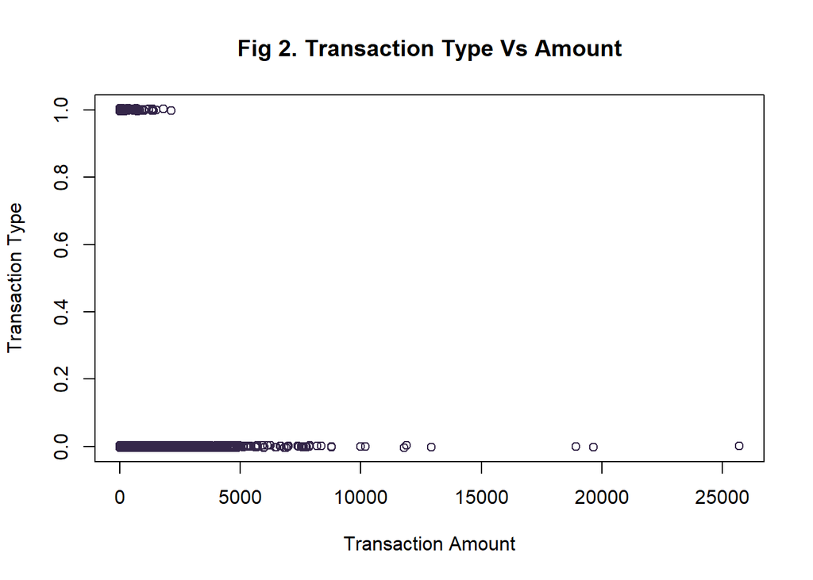

Overall, it seems that most fraudulent transactions involve relatively small amounts. However, as stated above, these can easily add up.

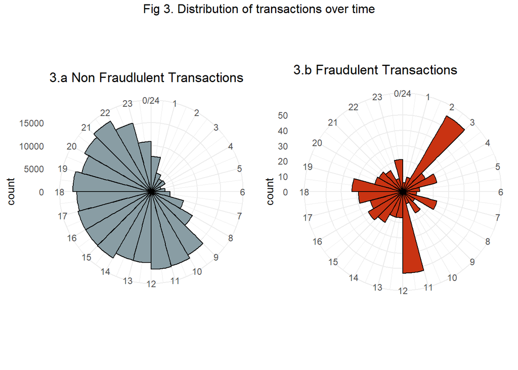

As we can see above, fraudulent transactions in contrast to non-fraudulent ones appear to have favorite times of the day. Most fraudulent transactions occur in the middle of the night (2-3 AM), the middle of the day (11:noon) and early in the evening(5:7 PM).